# Risk Factor Analysis

## Outcome Variable

**Outcome Variable:** stunted

## Predictor Variables

**Intervention Variable:** feducyrs

**Adjustment Set:**

unadjusted

## Stratifying Variables

The analysis was stratified on these variable(s):

- agecat
- studyid
- country

## Data Summary

| agecat | studyid | country | feducyrs | stunted | n_cell | n |
| --- | --- | --- | --- | --- | --- | --- |
| Birth | COHORTS | GUATEMALA | High | 0 | 146 | 804 |
| Birth | COHORTS | GUATEMALA | High | 1 | 9 | 804 |
| Birth | COHORTS | GUATEMALA | Low | 0 | 330 | 804 |
| Birth | COHORTS | GUATEMALA | Low | 1 | 25 | 804 |
| Birth | COHORTS | GUATEMALA | Medium | 0 | 280 | 804 |
| Birth | COHORTS | GUATEMALA | Medium | 1 | 14 | 804 |
| Birth | COHORTS | INDIA | High | 0 | 479 | 1354 |
| Birth | COHORTS | INDIA | High | 1 | 48 | 1354 |
| Birth | COHORTS | INDIA | Low | 0 | 392 | 1354 |
| Birth | COHORTS | INDIA | Low | 1 | 47 | 1354 |
| Birth | COHORTS | INDIA | Medium | 0 | 354 | 1354 |
| Birth | COHORTS | INDIA | Medium | 1 | 34 | 1354 |
| Birth | COHORTS | PHILIPPINES | High | 0 | 990 | 2873 |
| Birth | COHORTS | PHILIPPINES | High | 1 | 37 | 2873 |
| Birth | COHORTS | PHILIPPINES | Low | 0 | 758 | 2873 |
| Birth | COHORTS | PHILIPPINES | Low | 1 | 69 | 2873 |
| Birth | COHORTS | PHILIPPINES | Medium | 0 | 952 | 2873 |
| Birth | COHORTS | PHILIPPINES | Medium | 1 | 67 | 2873 |
| Birth | GMS-Nepal | NEPAL | High | 0 | 147 | 694 |
| Birth | GMS-Nepal | NEPAL | High | 1 | 25 | 694 |
| Birth | GMS-Nepal | NEPAL | Low | 0 | 235 | 694 |
| Birth | GMS-Nepal | NEPAL | Low | 1 | 61 | 694 |
| Birth | GMS-Nepal | NEPAL | Medium | 0 | 190 | 694 |
| Birth | GMS-Nepal | NEPAL | Medium | 1 | 36 | 694 |
| Birth | JiVitA-3 | BANGLADESH | High | 0 | 3509 | 21624 |
| Birth | JiVitA-3 | BANGLADESH | High | 1 | 1217 | 21624 |
| Birth | JiVitA-3 | BANGLADESH | Low | 0 | 6170 | 21624 |
| Birth | JiVitA-3 | BANGLADESH | Low | 1 | 3298 | 21624 |
| Birth | JiVitA-3 | BANGLADESH | Medium | 0 | 4854 | 21624 |
| Birth | JiVitA-3 | BANGLADESH | Medium | 1 | 2576 | 21624 |

[output cut: 300 more lines]

The following strata were considered:

- agecat: 24 months, studyid: COHORTS, country: GUATEMALA
- agecat: 24 months, studyid: COHORTS, country: INDIA
- agecat: 24 months, studyid: COHORTS, country: PHILIPPINES
- agecat: 24 months, studyid: GMS-Nepal, country: NEPAL
- agecat: 24 months, studyid: JiVitA-3, country: BANGLADESH
- agecat: 24 months, studyid: JiVitA-4, country: BANGLADESH
- agecat: 24 months, studyid: LCNI-5, country: MALAWI
- agecat: 24 months, studyid: MAL-ED, country: BANGLADESH
- agecat: 24 months, studyid: MAL-ED, country: INDIA
- agecat: 24 months, studyid: MAL-ED, country: NEPAL
- agecat: 24 months, studyid: MAL-ED, country: PERU
- agecat: 24 months, studyid: MAL-ED, country: SOUTH AFRICA
- agecat: 24 months, studyid: MAL-ED, country: TANZANIA, UNITED REPUBLIC OF
- agecat: 24 months, studyid: NIH-Crypto, country: BANGLADESH
- agecat: 24 months, studyid: PROBIT, country: BELARUS
- agecat: 24 months, studyid: PROVIDE, country: BANGLADESH
- agecat: 24 months, studyid: TanzaniaChild2, country: TANZANIA, UNITED REPUBLIC OF
- agecat: 24 months, studyid: ZVITAMBO, country: ZIMBABWE
- agecat: 6 months, studyid: COHORTS, country: GUATEMALA
- agecat: 6 months, studyid: COHORTS, country: INDIA
- agecat: 6 months, studyid: COHORTS, country: PHILIPPINES
- agecat: 6 months, studyid: GMS-Nepal, country: NEPAL
- agecat: 6 months, studyid: JiVitA-3, country: BANGLADESH
- agecat: 6 months, studyid: JiVitA-4, country: BANGLADESH
- agecat: 6 months, studyid: LCNI-5, country: MALAWI
- agecat: 6 months, studyid: MAL-ED, country: BANGLADESH
- agecat: 6 months, studyid: MAL-ED, country: INDIA
- agecat: 6 months, studyid: MAL-ED, country: NEPAL
- agecat: 6 months, studyid: MAL-ED, country: PERU
- agecat: 6 months, studyid: MAL-ED, country: SOUTH AFRICA
- agecat: 6 months, studyid: MAL-ED, country: TANZANIA, UNITED REPUBLIC OF
- agecat: 6 months, studyid: NIH-Crypto, country: BANGLADESH
- agecat: 6 months, studyid: PROBIT, country: BELARUS
- agecat: 6 months, studyid: PROVIDE, country: BANGLADESH
- agecat: 6 months, studyid: SAS-CompFeed, country: INDIA
- agecat: 6 months, studyid: SAS-FoodSuppl, country: INDIA
- agecat: 6 months, studyid: TanzaniaChild2, country: TANZANIA, UNITED REPUBLIC OF
- agecat: 6 months, studyid: ZVITAMBO, country: ZIMBABWE
- agecat: Birth, studyid: COHORTS, country: GUATEMALA
- agecat: Birth, studyid: COHORTS, country: INDIA
- agecat: Birth, studyid: COHORTS, country: PHILIPPINES
- agecat: Birth, studyid: GMS-Nepal, country: NEPAL
- agecat: Birth, studyid: JiVitA-3, country: BANGLADESH
- agecat: Birth, studyid: JiVitA-4, country: BANGLADESH
- agecat: Birth, studyid: MAL-ED, country: BANGLADESH
- agecat: Birth, studyid: MAL-ED, country: INDIA
- agecat: Birth, studyid: MAL-ED, country: NEPAL
- agecat: Birth, studyid: MAL-ED, country: PERU
- agecat: Birth, studyid: MAL-ED, country: SOUTH AFRICA
- agecat: Birth, studyid: MAL-ED, country: TANZANIA, UNITED REPUBLIC OF
- agecat: Birth, studyid: NIH-Crypto, country: BANGLADESH
- agecat: Birth, studyid: PROBIT, country: BELARUS
- agecat: Birth, studyid: PROVIDE, country: BANGLADESH
- agecat: Birth, studyid: SAS-CompFeed, country: INDIA
- agecat: Birth, studyid: ZVITAMBO, country: ZIMBABWE

### Dropped Strata

Some strata were dropped due to rare outcomes:

- agecat: Birth, studyid: MAL-ED, country: INDIA
- agecat: Birth, studyid: MAL-ED, country: NEPAL
- agecat: Birth, studyid: MAL-ED, country: PERU
- agecat: Birth, studyid: MAL-ED, country: SOUTH AFRICA
- agecat: Birth, studyid: MAL-ED, country: TANZANIA, UNITED REPUBLIC OF
- agecat: 6 months, studyid: MAL-ED, country: NEPAL
- agecat: 6 months, studyid: MAL-ED, country: SOUTH AFRICA
- agecat: 24 months, studyid: MAL-ED, country: TANZANIA, UNITED REPUBLIC OF
- agecat: 24 months, studyid: TanzaniaChild2, country: TANZANIA, UNITED REPUBLIC OF

## Methods Detail

We’re interested in the causal parameters $E[Y_a]$ for all values of $a \in \mathcal{A}$. These parameters represent the mean outcome if, possibly contrary to fact, we intervened to set all units to have $A=a$. Under the randomization and positivity assumptions, these are identified by the statistical parameters $\psi_a=E_W[E_{Y|A,W}(Y|A=a,W)]$. In addition, we’re interested in the mean of $Y$, $E[Y]$ under no intervention (the observed mean). We will estimate these parameters by using SuperLearner to fit the relevant likelihood factors – $E_{Y|A,W}(Y|A=a,W)$ and $p(A=a|W)$, and then updating our likelihood fit using a joint TMLE.

For unadjusted analyses ($W=\{\}$), initial likelihoods were estimated using Lrnr_glm to estimate the simple $E(Y|A)$ and Lrnr_mean to estimate $p(A)$. For adjusted analyses, a small library containing Lrnr_glmnet, Lrnr_xgboost, and Lrnr_mean was used.

Having estimated these parameters, we will then use the delta method to estimate relative risks and attributable risks relative to a prespecified baseline level of $A$.

# Results Detail

## Results Plots

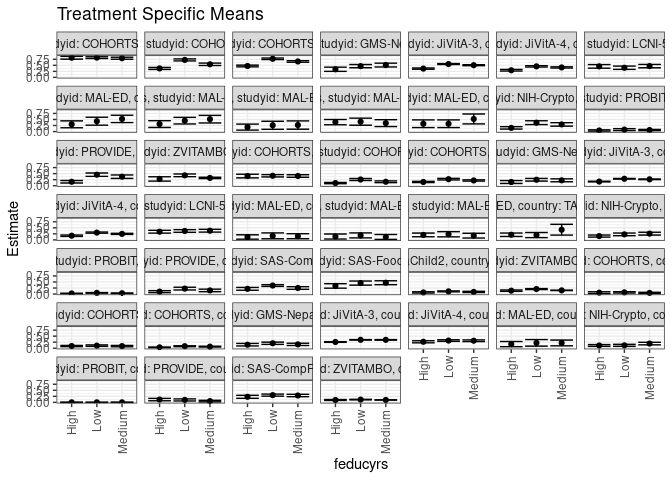

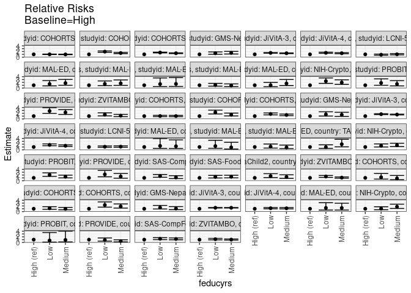

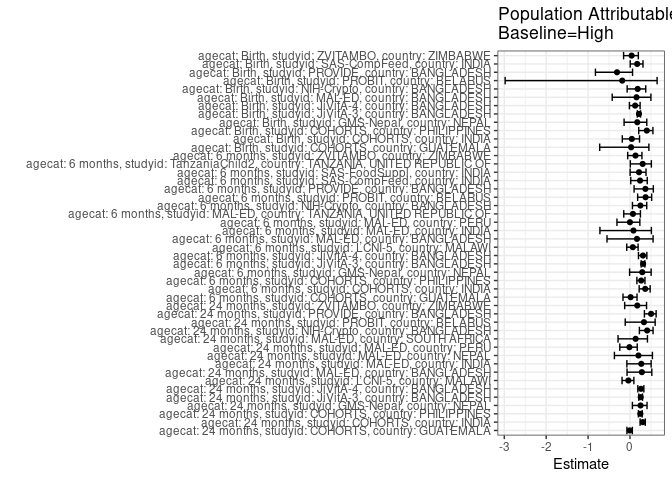

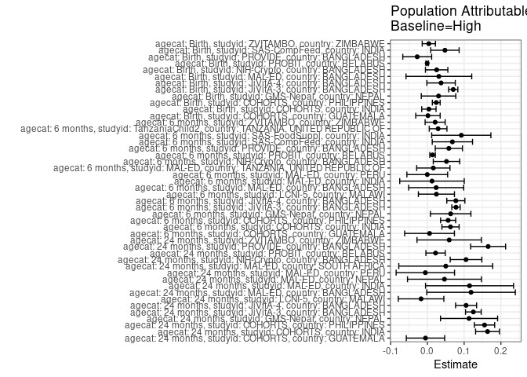

## Results Table

### Parameter: TSM

| agecat | studyid | country | intervention_level | baseline_level | estimate | ci_lower | ci_upper |
| --- | --- | --- | --- | --- | --- | --- | --- |
| Birth | COHORTS | GUATEMALA | High | NA | 0.0580645 | 0.0212246 | 0.0949044 |
| Birth | COHORTS | GUATEMALA | Low | NA | 0.0704225 | 0.0437906 | 0.0970545 |
| Birth | COHORTS | GUATEMALA | Medium | NA | 0.0476190 | 0.0232611 | 0.0719770 |
| Birth | COHORTS | INDIA | High | NA | 0.0910816 | 0.0665073 | 0.1156559 |
| Birth | COHORTS | INDIA | Low | NA | 0.1070615 | 0.0781278 | 0.1359952 |
| Birth | COHORTS | INDIA | Medium | NA | 0.0876289 | 0.0594838 | 0.1157739 |
| Birth | COHORTS | PHILIPPINES | High | NA | 0.0360273 | 0.0246277 | 0.0474268 |
| Birth | COHORTS | PHILIPPINES | Low | NA | 0.0834341 | 0.0645835 | 0.1022847 |
| Birth | COHORTS | PHILIPPINES | Medium | NA | 0.0657507 | 0.0505306 | 0.0809709 |
| Birth | GMS-Nepal | NEPAL | High | NA | 0.1453488 | 0.0926383 | 0.1980593 |
| Birth | GMS-Nepal | NEPAL | Low | NA | 0.2060811 | 0.1599682 | 0.2521940 |
| Birth | GMS-Nepal | NEPAL | Medium | NA | 0.1592920 | 0.1115472 | 0.2070369 |
| Birth | JiVitA-3 | BANGLADESH | High | NA | 0.2575116 | 0.2436710 | 0.2713523 |
| Birth | JiVitA-3 | BANGLADESH | Low | NA | 0.3483312 | 0.3377281 | 0.3589343 |
| Birth | JiVitA-3 | BANGLADESH | Medium | NA | 0.3467026 | 0.3347813 | 0.3586238 |
| Birth | JiVitA-4 | BANGLADESH | High | NA | 0.2663230 | 0.2233220 | 0.3093241 |
| Birth | JiVitA-4 | BANGLADESH | Low | NA | 0.3166969 | 0.2852118 | 0.3481820 |
| Birth | JiVitA-4 | BANGLADESH | Medium | NA | 0.3106061 | 0.2759976 | 0.3452145 |
| Birth | MAL-ED | BANGLADESH | High | NA | 0.1702128 | 0.0623508 | 0.2780748 |
| Birth | MAL-ED | BANGLADESH | Low | NA | 0.2222222 | 0.0858870 | 0.3585575 |
| Birth | MAL-ED | BANGLADESH | Medium | NA | 0.2173913 | 0.0977303 | 0.3370523 |
| Birth | NIH-Crypto | BANGLADESH | High | NA | 0.1126761 | 0.0758765 | 0.1494756 |
| Birth | NIH-Crypto | BANGLADESH | Low | NA | 0.1191489 | 0.0777006 | 0.1605973 |
| Birth | NIH-Crypto | BANGLADESH | Medium | NA | 0.1924883 | 0.1395059 | 0.2454707 |
| Birth | PROBIT | BELARUS | High | NA | 0.0029140 | -0.0013455 | 0.0071736 |
| Birth | PROBIT | BELARUS | Low | NA | 0.0020677 | 0.0002440 | 0.0038914 |
| Birth | PROBIT | BELARUS | Medium | NA | 0.0026468 | 0.0006929 | 0.0046007 |
| Birth | PROVIDE | BANGLADESH | High | NA | 0.1165644 | 0.0672552 | 0.1658736 |
| Birth | PROVIDE | BANGLADESH | Low | NA | 0.1016043 | 0.0582611 | 0.1449474 |
| Birth | PROVIDE | BANGLADESH | Medium | NA | 0.0529101 | 0.0209664 | 0.0848537 |

[output cut: 108 more lines]

### Parameter: E(Y)

| agecat | studyid | country | intervention_level | baseline_level | estimate | ci_lower | ci_upper |
| --- | --- | --- | --- | --- | --- | --- | --- |
| Birth | COHORTS | GUATEMALA | NA | NA | 0.0597015 | 0.0433139 | 0.0760891 |
| Birth | COHORTS | INDIA | NA | NA | 0.0952733 | 0.0796294 | 0.1109171 |
| Birth | COHORTS | PHILIPPINES | NA | NA | 0.0602158 | 0.0515157 | 0.0689159 |
| Birth | GMS-Nepal | NEPAL | NA | NA | 0.1757925 | 0.1474525 | 0.2041325 |
| Birth | JiVitA-3 | BANGLADESH | NA | NA | 0.3279227 | 0.3204672 | 0.3353781 |
| Birth | JiVitA-4 | BANGLADESH | NA | NA | 0.3036496 | 0.2833035 | 0.3239957 |
| Birth | MAL-ED | BANGLADESH | NA | NA | 0.2015504 | 0.1320546 | 0.2710462 |
| Birth | NIH-Crypto | BANGLADESH | NA | NA | 0.1379781 | 0.1129774 | 0.1629789 |
| Birth | PROBIT | BELARUS | NA | NA | 0.0024583 | 0.0007394 | 0.0041772 |
| Birth | PROVIDE | BANGLADESH | NA | NA | 0.0890538 | 0.0649864 | 0.1131212 |
| Birth | SAS-CompFeed | INDIA | NA | NA | 0.2786229 | 0.2475201 | 0.3097257 |
| Birth | ZVITAMBO | ZIMBABWE | NA | NA | 0.1028072 | 0.0976841 | 0.1079303 |
| 6 months | COHORTS | GUATEMALA | NA | NA | 0.4059735 | 0.3739435 | 0.4380034 |
| 6 months | COHORTS | INDIA | NA | NA | 0.1732852 | 0.1533446 | 0.1932258 |
| 6 months | COHORTS | PHILIPPINES | NA | NA | 0.2113885 | 0.1955816 | 0.2271953 |
| 6 months | GMS-Nepal | NEPAL | NA | NA | 0.2166963 | 0.1826342 | 0.2507583 |
| 6 months | JiVitA-3 | BANGLADESH | NA | NA | 0.2491941 | 0.2409375 | 0.2574508 |
| 6 months | JiVitA-4 | BANGLADESH | NA | NA | 0.2503732 | 0.2360124 | 0.2647340 |
| 6 months | LCNI-5 | MALAWI | NA | NA | 0.3633005 | 0.3301997 | 0.3964012 |
| 6 months | MAL-ED | BANGLADESH | NA | NA | 0.1439394 | 0.0838283 | 0.2040505 |
| 6 months | MAL-ED | INDIA | NA | NA | 0.1521739 | 0.0920273 | 0.2123205 |
| 6 months | MAL-ED | PERU | NA | NA | 0.2053571 | 0.1523375 | 0.2583768 |
| 6 months | MAL-ED | TANZANIA, UNITED REPUBLIC OF | NA | NA | 0.2288557 | 0.1706344 | 0.2870770 |
| 6 months | NIH-Crypto | BANGLADESH | NA | NA | 0.2097902 | 0.1799252 | 0.2396552 |
| 6 months | PROBIT | BELARUS | NA | NA | 0.0380013 | 0.0281677 | 0.0478349 |
| 6 months | PROVIDE | BANGLADESH | NA | NA | 0.1589404 | 0.1297581 | 0.1881227 |
| 6 months | SAS-CompFeed | INDIA | NA | NA | 0.2835709 | 0.2656121 | 0.3015297 |
| 6 months | SAS-FoodSuppl | INDIA | NA | NA | 0.4289474 | 0.3791199 | 0.4787748 |
| 6 months | TanzaniaChild2 | TANZANIA, UNITED REPUBLIC OF | NA | NA | 0.0966303 | 0.0837364 | 0.1095242 |
| 6 months | ZVITAMBO | ZIMBABWE | NA | NA | 0.1611105 | 0.1532617 | 0.1689592 |
| 24 months | COHORTS | GUATEMALA | NA | NA | 0.8084677 | 0.7839679 | 0.8329676 |
| 24 months | COHORTS | INDIA | NA | NA | 0.5347826 | 0.5084567 | 0.5611085 |
| 24 months | COHORTS | PHILIPPINES | NA | NA | 0.6279170 | 0.6082186 | 0.6476154 |
| 24 months | GMS-Nepal | NEPAL | NA | NA | 0.4496920 | 0.4054647 | 0.4939193 |
| 24 months | JiVitA-3 | BANGLADESH | NA | NA | 0.4888460 | 0.4756120 | 0.5020800 |
| 24 months | JiVitA-4 | BANGLADESH | NA | NA | 0.4009526 | 0.3835903 | 0.4183149 |
| 24 months | LCNI-5 | MALAWI | NA | NA | 0.4395797 | 0.3988336 | 0.4803258 |
| 24 months | MAL-ED | BANGLADESH | NA | NA | 0.4188034 | 0.3290222 | 0.5085847 |
| 24 months | MAL-ED | INDIA | NA | NA | 0.4242424 | 0.3396095 | 0.5088753 |
| 24 months | MAL-ED | NEPAL | NA | NA | 0.2307692 | 0.1437242 | 0.3178143 |
| 24 months | MAL-ED | PERU | NA | NA | 0.3841463 | 0.3094772 | 0.4588155 |
| 24 months | MAL-ED | SOUTH AFRICA | NA | NA | 0.3736264 | 0.2736811 | 0.4735717 |
| 24 months | NIH-Crypto | BANGLADESH | NA | NA | 0.2568093 | 0.2190047 | 0.2946140 |
| 24 months | PROBIT | BELARUS | NA | NA | 0.0669563 | 0.0407410 | 0.0931716 |
| 24 months | PROVIDE | BANGLADESH | NA | NA | 0.3287197 | 0.2903909 | 0.3670485 |
| 24 months | ZVITAMBO | ZIMBABWE | NA | NA | 0.3406524 | 0.3173794 | 0.3639255 |

### Parameter: RR

| agecat | studyid | country | intervention_level | baseline_level | estimate | ci_lower | ci_upper |
| --- | --- | --- | --- | --- | --- | --- | --- |
| Birth | COHORTS | GUATEMALA | High | High | 1.0000000 | 1.0000000 | 1.0000000 |
| Birth | COHORTS | GUATEMALA | Low | High | 1.2128326 | 0.5794578 | 2.5385159 |
| Birth | COHORTS | GUATEMALA | Medium | High | 0.8201058 | 0.3630178 | 1.8527290 |
| Birth | COHORTS | INDIA | High | High | 1.0000000 | 1.0000000 | 1.0000000 |
| Birth | COHORTS | INDIA | Low | High | 1.1754461 | 0.8023333 | 1.7220693 |
| Birth | COHORTS | INDIA | Medium | High | 0.9620919 | 0.6324750 | 1.4634900 |
| Birth | COHORTS | PHILIPPINES | High | High | 1.0000000 | 1.0000000 | 1.0000000 |
| Birth | COHORTS | PHILIPPINES | Low | High | 2.3158600 | 1.5698553 | 3.4163706 |
| Birth | COHORTS | PHILIPPINES | Medium | High | 1.8250272 | 1.2331192 | 2.7010561 |
| Birth | GMS-Nepal | NEPAL | High | High | 1.0000000 | 1.0000000 | 1.0000000 |
| Birth | GMS-Nepal | NEPAL | Low | High | 1.4178378 | 0.9258970 | 2.1711530 |
| Birth | GMS-Nepal | NEPAL | Medium | High | 1.0959292 | 0.6846285 | 1.7543248 |
| Birth | JiVitA-3 | BANGLADESH | High | High | 1.0000000 | 1.0000000 | 1.0000000 |
| Birth | JiVitA-3 | BANGLADESH | Low | High | 1.3526815 | 1.2724638 | 1.4379562 |
| Birth | JiVitA-3 | BANGLADESH | Medium | High | 1.3463568 | 1.2641977 | 1.4338554 |
| Birth | JiVitA-4 | BANGLADESH | High | High | 1.0000000 | 1.0000000 | 1.0000000 |
| Birth | JiVitA-4 | BANGLADESH | Low | High | 1.1891458 | 0.9866331 | 1.4332257 |
| Birth | JiVitA-4 | BANGLADESH | Medium | High | 1.1662757 | 0.9544426 | 1.4251239 |
| Birth | MAL-ED | BANGLADESH | High | High | 1.0000000 | 1.0000000 | 1.0000000 |
| Birth | MAL-ED | BANGLADESH | Low | High | 1.3055556 | 0.5404307 | 3.1539204 |
| Birth | MAL-ED | BANGLADESH | Medium | High | 1.2771739 | 0.5517153 | 2.9565485 |
| Birth | NIH-Crypto | BANGLADESH | High | High | 1.0000000 | 1.0000000 | 1.0000000 |
| Birth | NIH-Crypto | BANGLADESH | Low | High | 1.0574468 | 0.6561935 | 1.7040610 |
| Birth | NIH-Crypto | BANGLADESH | Medium | High | 1.7083333 | 1.1144965 | 2.6185840 |
| Birth | PROBIT | BELARUS | High | High | 1.0000000 | 1.0000000 | 1.0000000 |
| Birth | PROBIT | BELARUS | Low | High | 0.7095551 | 0.1438641 | 3.4996116 |
| Birth | PROBIT | BELARUS | Medium | High | 0.9082989 | 0.2074103 | 3.9776553 |
| Birth | PROVIDE | BANGLADESH | High | High | 1.0000000 | 1.0000000 | 1.0000000 |
| Birth | PROVIDE | BANGLADESH | Low | High | 0.8716578 | 0.4780080 | 1.5894865 |
| Birth | PROVIDE | BANGLADESH | Medium | High | 0.4539126 | 0.2171782 | 0.9486984 |

[output cut: 108 more lines]

### Parameter: PAR

| agecat | studyid | country | intervention_level | baseline_level | estimate | ci_lower | ci_upper |
| --- | --- | --- | --- | --- | --- | --- | --- |
| Birth | COHORTS | GUATEMALA | High | NA | 0.0016370 | -0.0315661 | 0.0348400 |
| Birth | COHORTS | INDIA | High | NA | 0.0041917 | -0.0152642 | 0.0236476 |
| Birth | COHORTS | PHILIPPINES | High | NA | 0.0241885 | 0.0135708 | 0.0348063 |
| Birth | GMS-Nepal | NEPAL | High | NA | 0.0304437 | -0.0165070 | 0.0773943 |
| Birth | JiVitA-3 | BANGLADESH | High | NA | 0.0704110 | 0.0579138 | 0.0829083 |
| Birth | JiVitA-4 | BANGLADESH | High | NA | 0.0373266 | -0.0013150 | 0.0759682 |
| Birth | MAL-ED | BANGLADESH | High | NA | 0.0313376 | -0.0580281 | 0.1207034 |
| Birth | NIH-Crypto | BANGLADESH | High | NA | 0.0253021 | -0.0051682 | 0.0557724 |
| Birth | PROBIT | BELARUS | High | NA | -0.0004558 | -0.0040331 | 0.0031216 |
| Birth | PROVIDE | BANGLADESH | High | NA | -0.0275106 | -0.0667544 | 0.0117331 |
| Birth | SAS-CompFeed | INDIA | High | NA | 0.0478537 | 0.0092667 | 0.0864406 |
| Birth | ZVITAMBO | ZIMBABWE | High | NA | 0.0040292 | -0.0139666 | 0.0220250 |
| 6 months | COHORTS | GUATEMALA | High | NA | 0.0059735 | -0.0616853 | 0.0736322 |
| 6 months | COHORTS | INDIA | High | NA | 0.0629911 | 0.0396174 | 0.0863648 |
| 6 months | COHORTS | PHILIPPINES | High | NA | 0.0565063 | 0.0359626 | 0.0770500 |
| 6 months | GMS-Nepal | NEPAL | High | NA | 0.0634116 | 0.0083512 | 0.1184720 |
| 6 months | JiVitA-3 | BANGLADESH | High | NA | 0.0778924 | 0.0665494 | 0.0892355 |
| 6 months | JiVitA-4 | BANGLADESH | High | NA | 0.0774888 | 0.0529088 | 0.1020688 |
| 6 months | LCNI-5 | MALAWI | High | NA | 0.0246551 | -0.0243947 | 0.0737048 |
| 6 months | MAL-ED | BANGLADESH | High | NA | 0.0239394 | -0.0508616 | 0.0987403 |
| 6 months | MAL-ED | INDIA | High | NA | 0.0126390 | -0.0750471 | 0.1003252 |
| 6 months | MAL-ED | PERU | High | NA | -0.0002503 | -0.0556943 | 0.0551936 |
| 6 months | MAL-ED | TANZANIA, UNITED REPUBLIC OF | High | NA | 0.0162573 | -0.0289964 | 0.0615110 |
| 6 months | NIH-Crypto | BANGLADESH | High | NA | 0.0520841 | 0.0161107 | 0.0880575 |
| 6 months | PROBIT | BELARUS | High | NA | 0.0141255 | 0.0066120 | 0.0216389 |
| 6 months | PROVIDE | BANGLADESH | High | NA | 0.0584619 | 0.0215291 | 0.0953947 |
| 6 months | SAS-CompFeed | INDIA | High | NA | 0.0680537 | 0.0132381 | 0.1228693 |
| 6 months | SAS-FoodSuppl | INDIA | High | NA | 0.0923137 | 0.0118662 | 0.1727612 |
| 6 months | TanzaniaChild2 | TANZANIA, UNITED REPUBLIC OF | High | NA | 0.0292449 | 0.0052051 | 0.0532846 |
| 6 months | ZVITAMBO | ZIMBABWE | High | NA | 0.0211787 | -0.0060414 | 0.0483988 |
| 24 months | COHORTS | GUATEMALA | High | NA | -0.0050916 | -0.0572412 | 0.0470580 |
| 24 months | COHORTS | INDIA | High | NA | 0.1637251 | 0.1312089 | 0.1962413 |
| 24 months | COHORTS | PHILIPPINES | High | NA | 0.1554859 | 0.1279093 | 0.1830626 |
| 24 months | GMS-Nepal | NEPAL | High | NA | 0.1134088 | 0.0357500 | 0.1910676 |
| 24 months | JiVitA-3 | BANGLADESH | High | NA | 0.1250779 | 0.1037941 | 0.1463617 |
| 24 months | JiVitA-4 | BANGLADESH | High | NA | 0.1053321 | 0.0767786 | 0.1338857 |
| 24 months | LCNI-5 | MALAWI | High | NA | -0.0170677 | -0.0789955 | 0.0448601 |
| 24 months | MAL-ED | BANGLADESH | High | NA | 0.1188034 | -0.0015854 | 0.2391922 |
| 24 months | MAL-ED | INDIA | High | NA | 0.1147186 | -0.0049691 | 0.2344063 |
| 24 months | MAL-ED | NEPAL | High | NA | 0.0465587 | -0.0539837 | 0.1471012 |
| 24 months | MAL-ED | PERU | High | NA | -0.0054640 | -0.0848577 | 0.0739297 |
| 24 months | MAL-ED | SOUTH AFRICA | High | NA | 0.0500970 | -0.0776070 | 0.1778009 |
| 24 months | NIH-Crypto | BANGLADESH | High | NA | 0.1051506 | 0.0621475 | 0.1481536 |
| 24 months | PROBIT | BELARUS | High | NA | 0.0222992 | -0.0039616 | 0.0485601 |
| 24 months | PROVIDE | BANGLADESH | High | NA | 0.1653534 | 0.1178885 | 0.2128183 |
| 24 months | ZVITAMBO | ZIMBABWE | High | NA | 0.0594024 | -0.0281234 | 0.1469283 |

### Parameter: PAF

| agecat | studyid | country | intervention_level | baseline_level | estimate | ci_lower | ci_upper |
| --- | --- | --- | --- | --- | --- | --- | --- |
| Birth | COHORTS | GUATEMALA | High | NA | 0.0274194 | -0.7228537 | 0.4509614 |
| Birth | COHORTS | INDIA | High | NA | 0.0439963 | -0.1835394 | 0.2277882 |
| Birth | COHORTS | PHILIPPINES | High | NA | 0.4016975 | 0.2086965 | 0.5476251 |
| Birth | GMS-Nepal | NEPAL | High | NA | 0.1731796 | -0.1407757 | 0.4007305 |
| Birth | JiVitA-3 | BANGLADESH | High | NA | 0.2147184 | 0.1758961 | 0.2517119 |
| Birth | JiVitA-4 | BANGLADESH | High | NA | 0.1229266 | -0.0139825 | 0.2413501 |
| Birth | MAL-ED | BANGLADESH | High | NA | 0.1554828 | -0.4245093 | 0.4993299 |
| Birth | NIH-Crypto | BANGLADESH | High | NA | 0.1833775 | -0.0677734 | 0.3754552 |
| Birth | PROBIT | BELARUS | High | NA | -0.1853945 | -2.9796979 | 0.6469179 |
| Birth | PROVIDE | BANGLADESH | High | NA | -0.3089213 | -0.8245750 | 0.0610006 |
| Birth | SAS-CompFeed | INDIA | High | NA | 0.1717507 | 0.0060591 | 0.3098212 |
| Birth | ZVITAMBO | ZIMBABWE | High | NA | 0.0391918 | -0.1528013 | 0.1992094 |
| 6 months | COHORTS | GUATEMALA | High | NA | 0.0147139 | -0.1668702 | 0.1680405 |
| 6 months | COHORTS | INDIA | High | NA | 0.3635110 | 0.2192300 | 0.4811299 |
| 6 months | COHORTS | PHILIPPINES | High | NA | 0.2673102 | 0.1648191 | 0.3572240 |
| 6 months | GMS-Nepal | NEPAL | High | NA | 0.2926289 | -0.0094480 | 0.5043094 |
| 6 months | JiVitA-3 | BANGLADESH | High | NA | 0.3125773 | 0.2663565 | 0.3558862 |
| 6 months | JiVitA-4 | BANGLADESH | High | NA | 0.3094931 | 0.2022294 | 0.4023347 |
| 6 months | LCNI-5 | MALAWI | High | NA | 0.0678641 | -0.0774250 | 0.1935613 |
| 6 months | MAL-ED | BANGLADESH | High | NA | 0.1663158 | -0.5487082 | 0.5512199 |
| 6 months | MAL-ED | INDIA | High | NA | 0.0830565 | -0.7177637 | 0.5105349 |
| 6 months | MAL-ED | PERU | High | NA | -0.0012190 | -0.3111145 | 0.2354295 |
| 6 months | MAL-ED | TANZANIA, UNITED REPUBLIC OF | High | NA | 0.0710373 | -0.1488645 | 0.2488482 |
| 6 months | NIH-Crypto | BANGLADESH | High | NA | 0.2482676 | 0.0584246 | 0.3998340 |
| 6 months | PROBIT | BELARUS | High | NA | 0.3717100 | 0.1825611 | 0.5170914 |
| 6 months | PROVIDE | BANGLADESH | High | NA | 0.3678230 | 0.0978977 | 0.5569817 |
| 6 months | SAS-CompFeed | INDIA | High | NA | 0.2399881 | 0.0184242 | 0.4115401 |
| 6 months | SAS-FoodSuppl | INDIA | High | NA | 0.2152099 | 0.0029784 | 0.3822645 |
| 6 months | TanzaniaChild2 | TANZANIA, UNITED REPUBLIC OF | High | NA | 0.3026470 | 0.0077055 | 0.5099226 |
| 6 months | ZVITAMBO | ZIMBABWE | High | NA | 0.1314546 | -0.0549521 | 0.2849238 |
| 24 months | COHORTS | GUATEMALA | High | NA | -0.0062978 | -0.0729166 | 0.0561845 |
| 24 months | COHORTS | INDIA | High | NA | 0.3061526 | 0.2414027 | 0.3653758 |
| 24 months | COHORTS | PHILIPPINES | High | NA | 0.2476218 | 0.2012884 | 0.2912674 |
| 24 months | GMS-Nepal | NEPAL | High | NA | 0.2521922 | 0.0574327 | 0.4067092 |
| 24 months | JiVitA-3 | BANGLADESH | High | NA | 0.2558636 | 0.2106194 | 0.2985146 |
| 24 months | JiVitA-4 | BANGLADESH | High | NA | 0.2627048 | 0.1873754 | 0.3310512 |
| 24 months | LCNI-5 | MALAWI | High | NA | -0.0388273 | -0.1897396 | 0.0929425 |
| 24 months | MAL-ED | BANGLADESH | High | NA | 0.2836735 | -0.0703303 | 0.5205931 |
| 24 months | MAL-ED | INDIA | High | NA | 0.2704082 | -0.0745957 | 0.5046469 |
| 24 months | MAL-ED | NEPAL | High | NA | 0.2017544 | -0.3717774 | 0.5354960 |
| 24 months | MAL-ED | PERU | High | NA | -0.0142239 | -0.2434698 | 0.1727583 |
| 24 months | MAL-ED | SOUTH AFRICA | High | NA | 0.1340830 | -0.2850876 | 0.4165284 |
| 24 months | NIH-Crypto | BANGLADESH | High | NA | 0.4094499 | 0.2244934 | 0.5502948 |
| 24 months | PROBIT | BELARUS | High | NA | 0.3330411 | -0.1138937 | 0.6006494 |
| 24 months | PROVIDE | BANGLADESH | High | NA | 0.5030224 | 0.3437692 | 0.6236283 |
| 24 months | ZVITAMBO | ZIMBABWE | High | NA | 0.1743785 | -0.1269728 | 0.3951487 |